# 1OVERVIEW

# 13LIMITATIONS OF THE PACKAGE

| Limitation | Why it is a problem |
| --- | --- |
| `peak_width` is chosen by the user | when `peak_width` is smaller than the widest peak, the peak survives the moving minimum, is taken as part of the concave region and is removed from the corrected spectrum |
| detection depends on the noise level | the threshold rises with the noise, so on noisy spectra a concave region is not flagged and stays under the plain rubberband line |
| noise is assumed independent and Gaussian | measured spectra such as SrE.IR do not meet this assumption, so the threshold may not be at the intended level |
| the baseline is made of straight lines | the hullBase baseline has corners at the hull points and is not a smooth curve |
| the input must be prepared | repeated wavenumbers, uneven spacing and transmittance spectra must be corrected by the user before calling `correct()` |

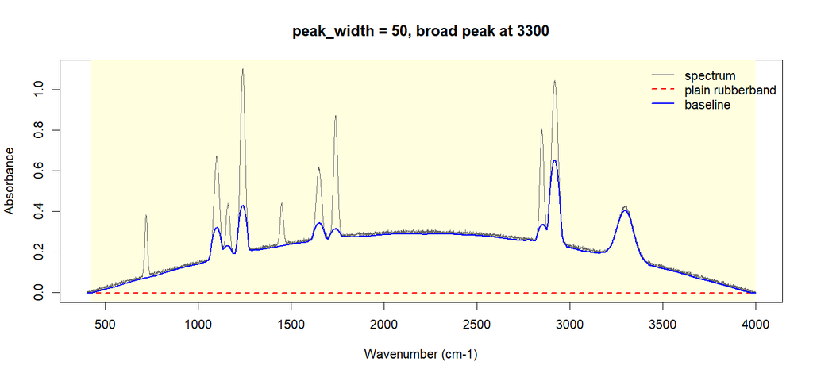

**Figure.** With peak_width = 50 on the simulated FTIR spectrum, the peaks are wider than the moving minimum window, so every hull segment is flagged and the hullBase baseline rises into the peaks.

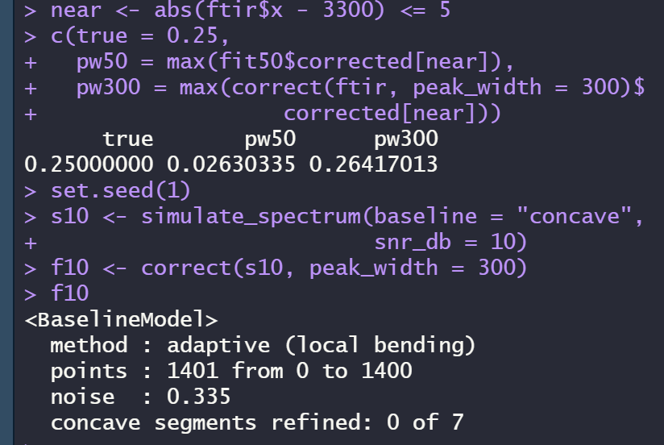

The peak at 3300 cm⁻¹ with a true height of 0.25 keeps a height of 0.026 with peak_width = 50 and 0.264 with peak_width = 300. On a simulated concave spectrum at 10 dB, `correct()` refines none of the seven hull segments.

## 13.1FUTURE IMPLEMENTATION

| Not yet evaluated | Future implementation |
| --- | --- |
| peak shapes other than Gaussian, such as Lorentzian or asymmetric peaks | add these peak shapes to `simulate_spectrum()` and repeat the evaluation on 300 simulated spectra |
| noise whose size changes across the spectrum | estimate the noise level separately for each hull segment, and test detection on simulated spectra with changing noise |
| measured spectra with a known reference baseline | evaluate the package on measured spectra whose reference baseline is known, so the baseline error can be calculated |
| comparison with other baseline methods | compare the package with other baseline correction methods, such as a penalised least squares baseline, on the same simulated and measured spectra |

# 14CONCLUSION

What the package does

- hullBase addresses one limitation of the plain rubberband baseline, a hull segment running straight underneath a concave region.
- `correct()` keeps the plain rubberband line on every hull segment and bends only the flagged segments.

What the package is

- hullBase is a refinement of the rubberband method, not a new baseline correction method.
- The lower convex hull is computed in the standard way, and the refinement is the local bending of flagged segments, with the bending strength calculated from the data.